# Principal Component Analysis

PCA

# 1 Introduction

- These notes follow notations used in this **recommended reading**: Section 12.1.1. of [Pattern Recognition and Machine Learning](https://www.microsoft.com/en-us/research/uploads/prod/2006/01/Bishop-Pattern-Recognition-and-Machine-Learning-2006.pdf) by Christopher Bishop.
- **Appendix C** of that same book also provides a reminder on Linear Algebra (e.g. eigenvectors of matrices etc.)
- Some of the results presented here are using the following **Linear Algebra Formula** showing how to differentiate w.r.t. a vector $\mathbf{x}$, where $\mathrm{A}$ is a matrix not depending on $\mathbf{x}$:

$$\frac{\partial
(\mathrm{A}\mathbf{x})}{\partial \mathbf{x}}=\mathrm{A}^{T} \quad
(\diamond)$$

$$\frac{\partial
(\mathbf{x}^{T}\mathrm{A})}{\partial \mathbf{x}}=\mathrm{A}\quad
(\diamond^2)$$
$$\frac{\partial
(\mathbf{x}^{T}\mathbf{x})}{\partial \mathbf{x}}=2 \mathbf{x} \quad
(\diamond^3)$$

$$\frac{\partial
(\mathbf{x}^{T}\mathrm{A}\mathbf{x})}{\partial \mathbf{x}}=\mathrm{A}
\mathbf{x}+\mathrm{A}^{T} \mathbf{x}\quad (\diamond^4)$$

- In addition [Lagrange multipliers](https://en.wikipedia.org/wiki/Lagrange_multiplier) are also used for computing PCA.

# 2 Definitions

## 2.1 Data

Consider that we have a set of vectors $\lbrace \mathbf{x}_n \rbrace _{n=1,\cdots ,N}$ in $\mathbb{R}^D$. This means that any vector $\mathbf{x}_n$ has $D$ coordinates as follows:
$$\mathbf{x}_n =
\left\lbrack
\begin{array}{c}
x_n[1]\\
x_n[2]\\
\vdots\\
x_n[D]\\
\end{array}
\right\rbrack$$

## 2.2 Mean

We can define the mean $\overline{\mathbf{x}}$ such that
$$\overline{\mathbf{x}}=\frac{1}{N}\sum_{n=1}^{N} \mathbf{x}_n$$
Spatially, the mean can be understood as the [center of gravity](https://en.wikipedia.org/wiki/Center_of_mass) of the clouds of points $\lbrace \mathbf{x}_n \rbrace _{n=1\cdots N}$.

$\overline{\mathbf{x}}$ is a also vector of dimension $D$:
$$\overline{\mathbf{x}} =
\left\lbrack
\begin{array}{c}
\frac{1}{N} \sum_{n=1}^N x_n[1]\\
\frac{1}{N} \sum_{n=1}^N x_n[2]\\
\vdots\\
\frac{1}{N} \sum_{n=1}^N x_n[D]\\
\end{array}
\right\rbrack$$

## 2.3 Covariance matrix

The covariance matrix $\mathrm{S}$ is defined as:
$$\mathrm{S}=\frac{1}{N} \sum_{n=1}^{N}
(\mathbf{x}_n-\overline{\mathbf{x}})
(\mathbf{x}_n-\overline{\mathbf{x}})^{T}$$

with defining $\mathbf{\tilde{x}}_n=\mathbf{x}_n-\mathbf{\overline{x}}$, $\forall n$ then
$$\mathrm{S}=\frac{1}{N} \sum_{n=1}^{N} \mathbf{\tilde{x}}_n \
\mathbf{\tilde{x}}_n^T$$
or
$$\mathrm{S}=\frac{1}{N} \sum_{n=1}^N
\left \lbrack
\begin{array}{cccc}
(\tilde{x}_{n}[1])^2 & (\tilde{x}_{n}[1]\times \tilde{x}_{n}[2])
&\cdots
&(\tilde{x}_{n}[1] \times \tilde{x}_{n}[D])\\
&&&\\
(\tilde{x}_{n}[2]\times \tilde{x}_{n}[1])&
(\tilde{x}_{n}[2])^2 &&\\
&&&\\
&&\ddots&\\
&&&\\
&&& (\tilde{x}_{n}[D])^2 \\
\end{array}
\right\rbrack$$

Defining the $D\times N$ matrix $\mathrm{\tilde{X}}=[\tilde{x}_{1},\cdots,\tilde{x}_{N}]$ then the covariance matrix is
$$\mathrm{S}=\frac{1}{N} \mathrm{\tilde{X}}\mathrm{\tilde{X}}^T$$
The covariance matrix $\mathrm{S}$ is of size $D\times D$.

# 3 Maximum variance formulation

Consider unit vector $\mathbf{u}_1$ (i.e. such that $\|\mathbf{u}_1\|^2=\mathbf{u}_1^T\mathbf{u}_1=1$).

The variance of the projected data is:
$$\frac{1}{N}\sum_{n=1}^N \left( \mathbf{u}_1^T\mathbf{x}_n -
\mathbf{u}_1^T\overline{\mathbf{x}} \right)^2 = \mathbf{u}_1^T
\mathrm{S}\ \mathbf{u}_1$$
We want to find the vector $\mathbf{u}_1$ such that:

$$\hat{\mathbf{u}}_1=\arg \max_{\mathbf{u}_1} \lbrace \mathbf{u}_1^T
\mathrm{S}\ \mathbf{u}_1\rbrace \quad \text{subject to} \quad
\|\mathbf{u}_1 \|^2=1$$
Introducing the Lagrange multiplier $\lambda_1$, this is the same as optimising:
$$\hat{\mathbf{u}}_1,\hat{\lambda}_1=\arg
\max_{\mathbf{u}_1,\lambda_1}\ \lbrace \
\mathcal{E}(\mathbf{u}_1,\lambda_1)=\mathbf{u}_1^T \mathrm{S}\
\mathbf{u}_1 +\lambda_{1} \ (1-\mathbf{u}_1^T\mathbf{u}_1 ) \ \rbrace$$
This means that we are looking for the vector $\mathbf{u}_1$ that maximizes the energy function $\mathcal{E}$.

## 3.1 Finding the first principal component

The solution is such that the derivatives of $\mathcal{E}$ are zeros, so we need to find $(\mathbf{u}_1,\lambda_1)$ such that:

$$\frac{\partial\mathcal{E}}{\partial \mathbf{u}_1}=0 \quad (\star)$$
and
$$\frac{\partial\mathcal{E}}{\partial \lambda_1}=0 \quad (\star \star)$$

### 3.1.1 Solving $(\star\star)$

$\lambda_1$ is a scalar so :
$$\frac{\partial\mathcal{E}}{\partial \lambda_1}=
(1-\mathbf{u}_1^T\mathbf{u}_1 )=0$$
and this differentiation w.r.t. the Lagrange multiplier $\lambda_1$ allows to recover the constraint
$$\mathbf{u}_1^T\mathbf{u}_1=\|\mathbf{u}_1\|^2=1$$

### 3.1.2 Solving $(\star)$

The derivative w.r.t. vector $\mathbf{u}_1$ can be computed using the Linear Algebra Formula provided in introduction:
$$\frac{\partial\mathcal{E}}{\partial
\mathbf{u}_1}=\underbrace{\frac{\partial (\mathbf{u}_1^T \mathrm{S}\
\mathbf{u}_1 )}{\partial \mathbf{u}_1}}_{(a)}
-\lambda_{1} \ \underbrace{\frac{\partial (\mathbf{u}_1^T\mathbf{u}_1
)}{\partial \mathbf{u}_1}}_{(b)}+\lambda_{1} \
\underbrace{\frac{\partial (1)}{\partial \mathbf{u}_1}}_{=0}$$

For computing (a) use the last formula $(\diamond^4)$

$$\frac{\partial (\mathbf{u}_1^T \mathrm{S}\ \mathbf{u}_1 )}{\partial
\mathbf{u}_1}
= \mathrm{S}\ \mathbf{u}_1 +\mathrm{S}^T\ \mathbf{u}_1=2\ \mathrm{S}\
\mathbf{u}_1$$
because the covariance matrix $\mathrm{S}$ is a $D\times D$ symmetric matrix hence $\mathrm{S}^T=\mathrm{S}$.

For computing (b) use the third formula $(\diamond^3)$

$$\frac{\partial (\mathbf{u}_1^T\mathbf{u}_1 )}{\partial \mathbf{u}_1}=2\
\mathbf{u}_1$$

### 3.1.3 Solution

The vector $\mathbf{u}_1$ that maximizes the variance is the eigenvector of the covariance matrix $\mathrm{S}$ with eigenvalue $\lambda_1$:
$$\mathrm{S}\ \mathbf{u}_1=\lambda_1\ \mathbf{u}_1$$

Eigenvalue $\lambda_1$ is also the variance of the projections:
$$\mathbf{u}_1^T\mathrm{S}\mathbf{u}_1=\lambda_1$$
$\lambda_1$ is the highest eigenvalue of $\mathrm{S}$.

## 3.2 How to find the direction with second most maximum variance?

Once we have the direction $\mathbf{u}_1$ with its associated eigenvalue $\lambda_1$ (variance of the projections of centered data on $\mathbf{u}_1$), the direction $\mathbf{u}_2$ with second maximum variance can be found such that:
$$\mathbf{u}_2^T\mathrm{S}\mathbf{u}_2$$
is maximised with the constraints $\|\mathbf{u}_2\|=1$ and $\mathbf{u}_2^T\mathbf{u}_1=0$ ($\mathbf{u}_2$ is orthogonal to $\mathbf{u}_1$).

# 4 Principal components

## 4.1 Computing PCA

From a set of vectors $\lbrace \mathbf{x}_n \rbrace_{n=1,\cdots,N}$

1. Compute the mean vector $\overline{\mathbf{x}}\in \mathbb{R}^D$
2. Center each vector observation $\mathbf{\tilde{x}}_n=\mathbf{x}_n-\overline{\mathbf{x}}$
3. Compute the covariance matrix
   $$\mathrm{S}=\frac{1}{N} \sum_{n=1}^{N} \mathbf{\tilde{x}}_n
   \mathbf{\tilde{x}}_n^T$$
4. Compute the eigenvectors of $\mathrm{S}$ and sort them from the one associated with the highest eigenvalue , to the one associated with the lowest eigenvalue.

$$\text{eigenvectors} \quad \equiv \quad \text{Principal components}$$

Note the $D$ principal components $\mathrm{U}=\lbrack\mathbf{u}_1, \mathbf{u}_2, \cdots, \mathbf{u}_D\rbrack$ of the covariance matrix $\mathrm{S}$ are sorted such that:
$$\lambda_{1}\geq \lambda_{2} \geq \cdots \geq \lambda_{D} \geq 0$$
with $\lambda_n$ the eigenvalue associated with eigenvector $\mathbf{u}_n$, $\forall n$.

## 4.2 Using PCA

Each vector in the set can be written as a linear combination of the mean and the eigenvectors:
$$\mathbf{x} = \overline{\mathbf{x}} +\sum_{j=1}^D \alpha_j\ \mathbf{u}_j$$
Principal components associated with highest $d$ eigenvalues provide a good reconstruction:
$$\mathbf{x} = \overline{\mathbf{x}} +\underbrace{\sum_{j=1}^d
\alpha_j\ \mathbf{u}_j}_{\text{reconstruction}}
+\underbrace{\sum_{j=d+1}^D
\alpha_j\ \mathbf{u}_j}_{\text{reconstruction error} }$$

# 5 Applications

- Compression / Dimensionality reduction
- Visualisation of data distribution
- Example PCA applied to images of faces : https://en.wikipedia.org/wiki/Eigenface
- see Python examples
  - https://scikit-learn.org/stable/auto_examples/decomposition/plot_faces_decomposition.html#sphx-glr-auto-examples-decomposition-plot-faces-decomposition-py
  - https://scikit-learn.org/stable/auto_examples/datasets/plot_iris_dataset.html#sphx-glr-auto-examples-datasets-plot-iris-dataset-py

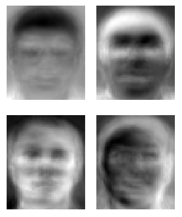

# 6 Questions

- What is the dimension of the matrix $\tilde{\mathrm{X}}$?
- What is the dimension of the covariance matrix $\mathrm{S}$?
- What are the properties of the covariance matrix $\mathrm{S}$?